# Chapter 3 & 4 Exercises

C組 連昱婷、劉心雨、莊芸綺

2020/4/7

## Chapter 3

## Question 1

Supposing that you are given x, write an R expression for y using if statements.  
Add your expression for y to the following program, then run it to plot the function f.

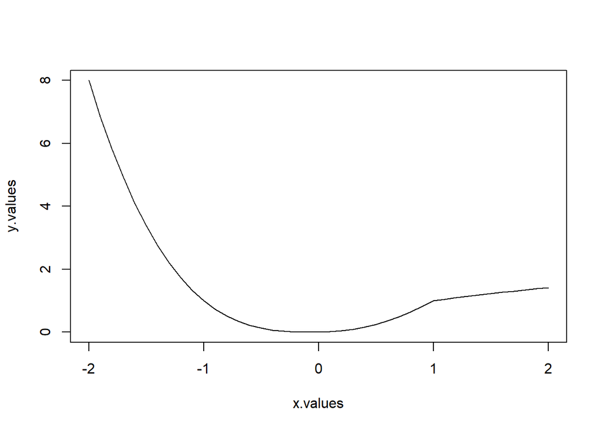

```r
x.values <- seq(-2, 2, by = 0.1)
# for each x calculate y
n <- length(x.values)
y.values <- rep(0, n)
for (i in 1:n) {
  #x <- x.values[i]
  if(x.values[i] <= 0){
    y <- -x.values[i]^3
  }
  else if((x.values[i] > 0)&(x.values[i] <= 1)){
    y <- x.values[i]^2
  }
  else{
    y <- sqrt(x.values[i])
  }
  y.values[i] <- y
}
# output
plot(x.values, y.values, type = "l")
```

## Question 2

Let $h(x, n) = 1+x+x^{2}+...+x^{n} = \sum_{i=0}^{n}x^{i}$.  
Write an R program to calculate $h(x, n)$ using a for loop.

```r
x <- 6.6
n <- 8
sum <- 0


for(i in 1:n)
{
  sum <- sum + x^i
  #i <- i+1
}
print(sum)
```

```
## [1] 4243335
```

## Question 3

The function $h(x, n)$ from Exercise 2 is the finite sum of a geometric sequence.  
It has the following explicit formula, for $x \neq 1$.  
$h(x,n)=\frac{1-x^{n+1}}{1-x}$  
Test your program from Exercise 2 against this formula using the following values.

```r
x <- 6.6
n <- 8
sum <- 0
i <- 0

while(i!=n+1)
{
  sum <- sum + x^i
  i <- i+1
}
print(sum)
```

```
## [1] 4243336
```

```r
h <- (1-x^(n+1))/(1-x)
print(h)
```

```
## [1] 4243336
```

## Question 4

First write a program that achieves the same result as in Exercise 2 but using a while loop.  
Then write a program that does this using vector operations (and no loops).

```r
x <- 6.6
n <- 8
sum <- 0
i <- 0

while(i!=n+1)
{
  sum <- sum + x^i
  i <- i+1
}
print(sum)
```

```
## [1] 4243336
```

## Question 5

To rotate a vector $(x, y)^{T}$ anticlockwise by $\theta$ radians, you premultiply it by the matrix.

```r
theta <- pi/2  #let theta = 90 degree
x <- matrix(c(1,0),2,1)  #設一個2x1的矩陣為1,0
print(x)  #輸出矩陣
```

```
##      [,1]
## [1,]    1
## [2,]    0
```

```r
a <- floor(cos(theta))  #利用floor取底函數取出cos(pi/2)最近的值,存入a
b <- sin(theta)  #將sin(pi/2)值存入b
m <- matrix(c(a,b,-b,a),2,2)  #將旋轉矩陣存入m
#print(m)
print(m%*%x)  #矩陣相乘,求得結果
```

```
##      [,1]
## [1,]    0
## [2,]    1
```

## Question 6

Check that if the $x_{i}$ are all positive, the harmonic mean is always less than or equal to the geometric mean,  
which is always less than or equal to the arithmetic mean.

```r
Geomatric_Mean <- function(n){
  x <- seq(1:10)
  #print(x)
  sum <- x[1]
  for(i in 2:n){
    sum <- sum * x[i]
  }
  return(sum^(1/n))
}

Harmonic_Mean <- function(m){
  x <- seq(1:10)
  sum <- 1/x[1]
  for(j in 2:m){
    sum <- sum + 1/x[j]
  }
  return(m/sum)
}

Arithmetic_Mean <- function(a){

  x <- seq(1:10)
  sum <- x[1]
  for(k in 2:a){
    sum <- sum + x[a]
  }
  return(sum/a)
}

value <- 5  #scan()

print(Geomatric_Mean(value))
```

```
## [1] 2.605171
```

```r
print(Harmonic_Mean(value))
```

```
## [1] 2.189781
```

```r
print(Arithmetic_Mean(value))
```

```
## [1] 4.2
```

## Question 7

How would you find the sum of every third element of a vector x?

```r
x <- seq(1,10)  #將x設為1-10數列,依序存入
sum <- 0  #歸零,用來紀錄總和
print(x)  #先將x輸出,觀察數列以便檢查底下有無計算錯誤
```

```
##  [1]  1  2  3  4  5  6  7  8  9 10
```

```r
for(i in 1:10)  #從第一個位置開始檢查
{
  if(i %% 3 == 0)  #若位置為3的倍數
    {sum <- sum + x[i]}  #做加總
}
print(sum)  #輸出加總後的結果
```

```
## [1] 18
```

## Question 10

Write a program that uses a loop to find the minimum of a vector x, without using any predefined functions like min(…) or sort(…).  
You will need to define a variable, x.min say, in which to keep the smallest value you have yet seen.  
Start by assigning x.min <- x[1] then use a for loop to compare x.min with x[2], x[3], etc.  
If/when you find x[i] < x.min, update the value of x.min accordingly.

```r
#利用迴圈找最小值
x<-c(3,1,6,7,0,4)  #隨意給定x值,此為{3,1,6,7,0,4},6個數字
x.min<-x[1]  #先將x第一個位置的值=3設為最小值
for(i in 2:6)  #從第一個位置檢查到第六個位置
{
  if(x[i]<x.min)  #若第i個位置的值小於目前最小值
    x.min<-x[i]  #讓最小值變為第i位置的值
}
print(x.min)  #輸出最小值
```

```
## [1] 0
```

## Question 12

The game of craps is played as follows. First, you roll two six-sided dice; let x be the sum of the dice on the first roll.  
If x = 7 or 11 you win, otherwise you keep rolling until either you get x again, in which case you also win,  
or until you get a 7 or 11, in which case you lose.  
Write a program to simulate a game of craps.You can use the following snippet of code to simulate the roll of two (fair) dice:  
x <- sum(ceiling(6*runif(2)))

```r
rm(list = ls())
x <- sum(ceiling(6*runif(2)))
n <- x
if (x == 7 || x == 11)
{print("you are win.")} else {
  while(TRUE)
  {
    x <- sum(ceiling(6*runif(2)))

    if(x == n)
    {
      print("you are win.")
      break
    }
    if(x == 7 || x == 11)
    {
      print("you are lose.")
      break
    }
  }
}
```

```
## [1] "you are win."
```

## Question 13

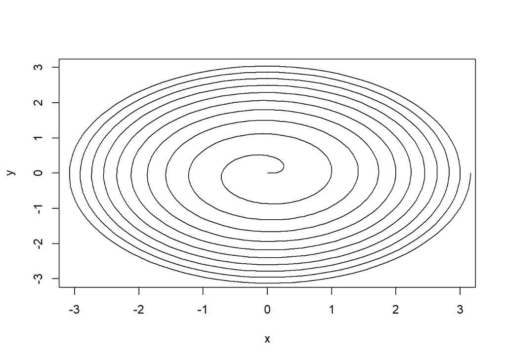

```r
rm(list = ls())
t <- seq(0,10,by = 0.01)
r <- sqrt(t)
Q <- 2*pi*t
x <- r*cos(Q)
y <- r*sin(Q)
plot(c(-3:3),c(-3:3),type="n",xlab="x",ylab="y")
lines(x,y)
```

End of chpater 3 exercises.

## Chapter 4

## Question 1

```r
ID <- seq(1:10)
Age <- seq(from=18,to=9)
NumTeeth <- seq(from = 32, to = 23)


#write(teeth, file = "teeth.txt", ncolumns=1)
#print(read.table("teeth.txt"))
#Age <- read.table("teeth.txt")

#write(age, file = "age.txt", ncolumns=1)
#Teeth <- read.table("age.txt")
#print(read.table("age.txt"))

print(data.frame(ID,Age,NumTeeth))
```

```
##    ID Age NumTeeth
## 1   1  18       32
## 2   2  17       31
## 3   3  16       30
## 4   4  15       29
## 5   5  14       28
## 6   6  13       27
## 7   7  12       26
## 8   8  11       25
## 9   9  10       24
## 10 10   9       23
```

## Question 2

The function $order(x)$ returns a permutation of $1:length(x)$ giving the order of the elements of x.

```r
#x <- c(ID,Age,NumTeeth)
#y <- order(x==Age)
print(Age)
```

```
##  [1] 18 17 16 15 14 13 12 11 10  9
```

## Question 3

Devise a program that outputs a table of squares and cubes of the numbers 1 to n. For n <- 7 the output should be as follows:

```r
number<-c(1:7)  #將number設為{1,2,3,4,5,6,7}
square<-number^2  #將number所有數字作平方,存入square
cube<-number^3  #將number所有數字作三次方,存入cube
print(data.frame(number,square,cube))  #將結果依格式函數data.frame()輸出
```

```
##   number square cube
## 1      1      1    1
## 2      2      4    8
## 3      3      9   27
## 4      4     16   64
## 5      5     25  125
## 6      6     36  216
## 7      7     49  343
```

## Question 4

Write an R program that prints out the standard multiplication table:

```r
m1 = matrix(1:9, nrow=9, byrow=TRUE)  #將{1,2,3,4,5,6,7,8,9}存入m1矩陣(9行)
m2 = matrix(1:9, nrow=1, byrow=TRUE)  #將{1,2,3,4,5,6,7,8,9}存入m2矩陣(9列)
print(m1%*%m2) #m1&m2矩陣相乘即可得出乘法表
```

```
##       [,1] [,2] [,3] [,4] [,5] [,6] [,7] [,8] [,9]
##  [1,]    1    2    3    4    5    6    7    8    9
##  [2,]    2    4    6    8   10   12   14   16   18
##  [3,]    3    6    9   12   15   18   21   24   27
##  [4,]    4    8   12   16   20   24   28   32   36
##  [5,]    5   10   15   20   25   30   35   40   45
##  [6,]    6   12   18   24   30   36   42   48   54
##  [7,]    7   14   21   28   35   42   49   56   63
##  [8,]    8   16   24   32   40   48   56   64   72
##  [9,]    9   18   27   36   45   54   63   72   81
```

## Question 5

Use R to plot the hyperbola $x^{2}$ − $\frac{y^{2}}{3}$ = 1

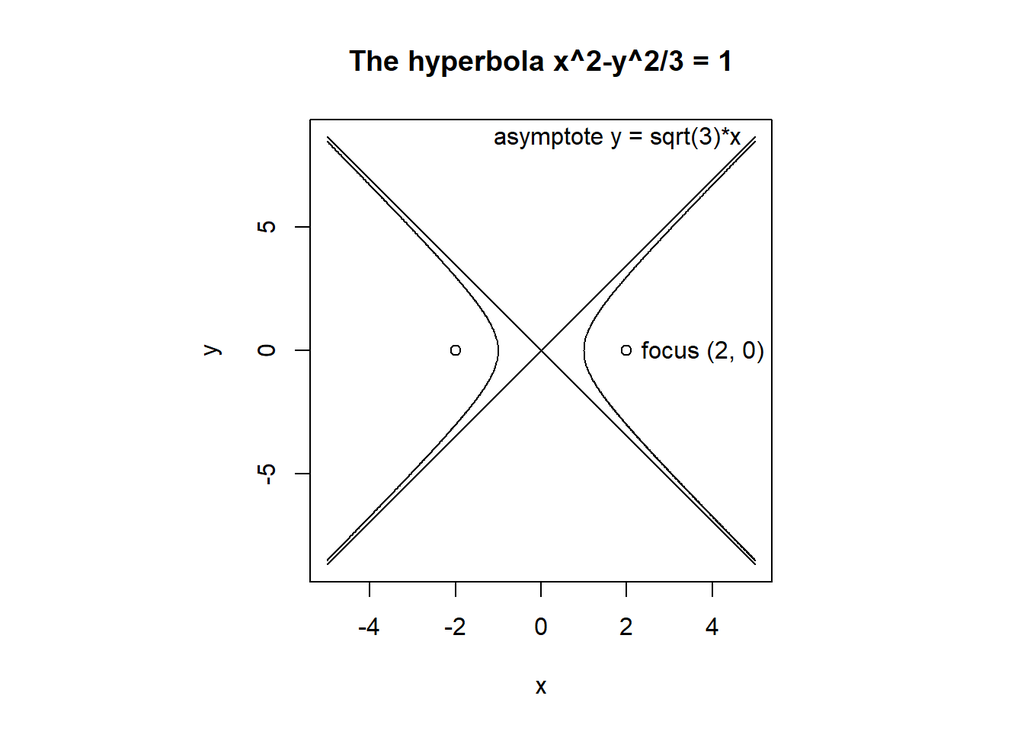

```r
 x <- seq(1,5, by = 0.01)
 y.upper <-  sqrt(3*x^2-3)
 y.lower <- -sqrt(3*x^2-3)
 x.max <- max(x)
 y.max <- sqrt(3)*x.max
 x.min <- -x.max
 y.min <- -y.max
 par(pty = "s")
 plot(c(x.min,x.max), c(y.min,y.max), type = "n", xlab = "x", ylab = "y")

 lines(x, y.upper)
 lines(x, y.lower)
 lines(-x, y.upper)
 lines(-x, y.lower)

 segments(x.min,y.min,x.max,y.max)
 segments(x.min,y.max,x.max,y.min)

 points(2, 0)
 points(-2, 0)
 text(2, 0, "focus (2, 0)", pos = 4)
 text(x.max,y.max, "asymptote y = sqrt(3)*x", pos  = 2)
 title("The hyperbola x^2-y^2/3 = 1")
```

End of chpater 4 exercises.